# Capture-Mark-Recapture practical

## Generating capture histories

Install and load the packages we will be using in today’s practical: *marked* for the CMR analysis, *tidyr* and *dplyr* for data manipulation, and *ggplot2* for plotting.

```r
rm(list=ls(all=TRUE))

my_packages <- c('dplyr', 'tidyr', 'marked', 'ggplot2')
new_packages <- my_packages[!(my_packages %in% installed.packages()[,'Package'])]
if(length(new_packages)) install.packages(new_packages)

library(dplyr)
library(tidyr)
library(marked)
library(ggplot2)
```

Load the sparrow recapture dataset - you’ll need to edit the file path to direct R to wherever you saved the data file.

```r
longdata <- read.table("~/Dropbox/Hannah/Work URF/Teaching/MSc Biodiversity under pressure/2025/For upload/CMR practical/sparrowrecap.txt", header = TRUE, sep = '\t')
head(longdata)
```

```
##      id year     island    sex
## 1 11243 1998 Hestmannoy Female
## 2 10905 1998     Gjeroy Female
## 3 10026 1998     Gjeroy   Male
## 4  2580 1998     Gjeroy   Male
## 5  4836 1998     Gjeroy Female
## 6  3342 1998     Gjeroy Female
```

The dataset consists of n=1582 capture observations across different islands in the house sparrow meta-population. These data are in what is known as ‘long format’, with individuals appearing in multiple rows representing each occasion they were captured. First a bit of simple data exploration:

```r
length(unique(longdata$id)) # the number of unique individuals in the dataframe
```

```
## [1] 1062
```

```r
table(longdata$sex) # similar number of observations of males and females
```

```
##
## Female   Male
##    790    792
```

```r
table(longdata$year) # captures from 1998-2007
```

```
##
## 1998 1999 2000 2001 2002 2003 2004 2005 2006 2007
##  141  218  221  144  134   97  140  131  168  188
```

```r
table(longdata$island) # at 4 different island locations
```

```
##
##     Gjeroy Hestmannoy     Kvaroy      Myken
##        394        871        218         99
```

*marked* requires capture histories to be in ‘wide’ format, with each row representing one individual. The capture history forms a string of 1s and 0s with no spaces, with a 1 for each capture or sighting and a 0 when an individual wasn’t detected. All histories should have the same number of entries and therefore be the same length. They should appear in the first column of the dataframe which must be named ‘ch’. The following code uses functions from the *tidyr* and *dplyr* packages to generate the appropriate format (don’t worry about the details).

```r
temp <- longdata[,1:2]
temp$detect <- 1
temp <- temp %>%
  distinct() %>%
  spread(year, detect, fill = 0) %>%
  group_by(id) %>%
  unite("ch", 2:tail(names(.),1), sep = "")

sparrow <- as.data.frame(temp) # new dataframe called sparrow
head(sparrow)
```

```
##    id         ch
## 1   1 0000100100
## 2  14 0001000000
## 3  18 1000000000
## 4  24 0000001000
## 5  57 0000001000
## 6 100 0000100000
```

We will now add back some information based on the individual ids using the match() function.

```r
sparrow$island <- longdata$island[match(sparrow$id, longdata$id)]
# this creates a new column called island in the sparrow df...
# using the entry from the island column in the longdata df...
# where id in the sparrow df matches the id in the longdata df

sparrow$sex <- as.factor(longdata$sex[match(sparrow$id, longdata$id)])

sparrow <- droplevels(subset(sparrow, select = -id)) # remove id column so capture histories appear in first column
head(sparrow)
```

```
##           ch     island    sex
## 1 0000100100 Hestmannoy   Male
## 2 0001000000      Myken Female
## 3 1000000000 Hestmannoy   Male
## 4 0000001000      Myken Female
## 5 0000001000     Gjeroy   Male
## 6 0000100000 Hestmannoy   Male
```

We are now ready to run a simple Capture-Mark-Recapture analysis.

## Simple Cormack-Jolly-Seber model

A CJS model estimates apparent survival (Phi) and detection probability (p) for open populations. Each of these is a linear model on the logit scale (bound between 0 and 1). This is the same transformation or ‘link function’ used in a binomial Generalised Linear Model (GLM), and the same approach you used to model presence/absence data in the species distribution modelling workshop.

The CJS model uses information from capture histories where individuals were marked, not observed, and subsequently seen at a later date to estimate detection probabilities. For example, comparing the number of individuals with a capture history of 101 vs 111 is informative about detection probability on the second sampling event.

The most basic form of the model (the default) estimates constant survival and detection probabilities.

```r
mod1 <- crm(sparrow) # capture-mark-recapture (cmr) model
mod1 # examine model and coefficient estimates
```

```
##
## crm Model Summary
##
## Npar :  2
## -2lnL:  2450.35
## AIC  :  2454.35
##
## Beta
##                   Estimate
## Phi.(Intercept) 0.07109326
## p.(Intercept)   0.32242446
```

```r
mod1 <- cjs.hessian(mod1) # refit model with precision estimates
```

As with a binomial GLM, these estimates are on the latent (logit) scale. We can transform them back to the data scale using the plogis() or predict() functions. The estimates on the data scale are also stored within the results section of the model under ‘reals’.

```r
mod1$results$reals
```

```
## $Phi
##   occ  estimate
## 1   9 0.5177658
##
## $p
##   occ estimate
## 1  10 0.579915
```

```r
plogis(mod1$results$beta$Phi)
```

```
## (Intercept)
##   0.5177658
```

```r
plogis(mod1$results$beta$p)
```

```
## (Intercept)
##    0.579915
```

```r
predict(mod1, newdata=data.frame(sex = c('Female', 'Male')), se=T) # N.b. In this case, there are no groups or covariates in the model and so the 'newdata' argument is not used
```

```
## $Phi
##   occ  estimate         se       lcl       ucl
## 1   1 0.5177658 0.01548383 0.4873893 0.5480116
##
## $p
##   occ estimate         se       lcl       ucl
## 1   2 0.579915 0.02558621 0.5291095 0.6290816
```

#### *QUESTION: What was the average survival probability? What about the average detection probability?*

**Click me**

The probability of surviving between capture events was 0.518, and the probability of detecting an animal during a capture event was 0.580.

#### *QUESTIONS: This model assumed constant survival rates and detection probabilities. Is this a realistic assumption for this system? What term might you include in the model next, and why?*

Try answering these questions yourself before reading on.

## Including static covariates

The islands in the meta-population are all different, and it is possible that the probability of capturing an individual differs between islands. We can test this by adding some additional complexity to our model and allowing the detection probability to vary between islands.

In the *marked* package, this is a three stage process: (1) data processing, (2) building the design matrix, (3) set up and execute candidate models. Many R packages do a lot of this kind of data processing ‘under the hood’ so you don’t have to code the individual steps. *marked* is a little more demanding, but it has built-in functions that can help (‘process.data’ and ‘make.design.matrix’). Examining the outputs of the functions can help you understand what they are doing. The outputs are lists, rather than dataframes. You can examine the different components of the lists using double square brackets or by naming them with the $ sign. You can also type ?process.data or ?make.design.matrix to get more information on these functions.

```r
sparrow.proc <- process.data(sparrow) # built in function for data processing
```

[output not shown]

```r
str(sparrow.proc)
head(sparrow.proc[[1]])
head(sparrow.proc$data)

sparrow.ddl <- make.design.data(sparrow.proc) # built in function for building design matrix
str(sparrow.ddl)
head(sparrow.ddl[[1]])
head(sparrow.ddl$Phi)
```

We can then specify the model formulation for the detection probability model, making p dependent on island. Finally, we run the CMR model using our newly processed data, our design matrix, and our model specification.

```r
# specify model formulation: capture probability depends on island
p.island <- list(formula=~island)

mod2 <- crm(sparrow.proc,
            sparrow.ddl,
            model.parameters = list(p = p.island),
            accumulate=FALSE, hessian = TRUE)
```

```r
mod2$results$reals
```

```
## $Phi
##   occ  estimate         se       lcl       ucl
## 1   9 0.5283196 0.01568363 0.4975112 0.5589139
##
## $p
##       island occ  estimate         se       lcl       ucl
## 1     Gjeroy  10 0.6407406 0.04085332 0.5574277 0.7163506
## 2 Hestmannoy  10 0.6124055 0.03379869 0.5444692 0.6762348
## 3     Kvaroy  10 0.4577020 0.06121046 0.3423258 0.5778007
## 4      Myken  10 0.1750597 0.04740612 0.1003280 0.2876586
```

#### *QUESTIONS: Does it look like detection probability varies among islands? Which island has the lowest detection probability? Why might this be?*

How do we decide whether to use the model with a constant detection probability, or where detection probability varies between islands? We might decide from the outset that we should account for variation between islands based on our understanding of the study system - because aspects of the data collection mean that differences are very likely. A more data-driven approach might be to look at the differences in the estimated detection probability for the four islands. These are quite large and often the 95% confidence intervals do not overlap, indicating substantial differences.

Another data-driven approach would be to use something called Akaike’s Information Criterion (AIC) to help us distinguish the best model - i.e. the one that explains more variation in the data. AIC values are calculated from the log-likelihood of a model, with a penalisation for increased complexity (a higher number of parameters). AIC values are not meaningful in themselves but can be used to compare different models - as long as the models are fitted to exactly the same dataset using maximum likelihood estimation. Lower AIC values indicate a better fitting model.

```r
(mod2$results$AIC) # detection probability depends on island
```

```
## [1] 2422.957
```

```r
(mod1$results$AIC) # constant detection probability
```

```
## [1] 2454.35
```

In this case, the more complex model with different detection probabilities for each island has a lower AIC value. This indicates a better fit to the data and we therefore accept this model.

#### *TASK: Test whether survival probabilities differ between the islands*

Try coding this yourself before clicking below to reveal the answer. Use the code above as a guide.

Hint: first include the island term in the survival (Phi) model, then compare the AIC value with mod2 to see if this improves model fit.

**Click me**

```r
sparrow.proc <- process.data(sparrow)
sparrow.ddl <- make.design.data(sparrow.proc)

Phi.island <- list(formula=~island) # survival probability depends on island
p.island <- list(formula=~island) # detection probability depends on island

mod3 <- crm(sparrow.proc,
            sparrow.ddl,
            model.parameters = list(Phi = Phi.island,
                                    p = p.island),
            accumulate=FALSE, hessian = TRUE)
```

```
##  Number of evaluations:  100  -2lnl: 2423.254961 Number of evaluations:  200  -2lnl: 2407.197522 Number of evaluations:  300  -2lnl: 2407.195435 Number of evaluations:  400  -2lnl: 2407.226418 Number of evaluations:  500  -2lnl: 2407.204705
```

```
##  Number of evaluations:  100  -2lnl: 2407.309908 Number of evaluations:  200  -2lnl:  2407.20348
```

```r
mod3$results$reals
```

```
## $Phi
##       island occ  estimate         se       lcl       ucl
## 1     Gjeroy   9 0.5742467 0.02826611 0.5181411 0.6285035
## 2 Hestmannoy   9 0.5123377 0.02078664 0.4716042 0.5529081
## 3     Kvaroy   9 0.4615812 0.04645781 0.3727655 0.5529047
## 4      Myken   9 0.6018271 0.09959821 0.4009393 0.7734194
##
## $p
##       island occ  estimate         se        lcl       ucl
## 1     Gjeroy  10 0.6134898 0.04445464 0.52361988 0.6962410
## 2 Hestmannoy  10 0.6247979 0.03501890 0.55408143 0.6905628
## 3     Kvaroy  10 0.5236326 0.07763494 0.37392384 0.6692116
## 4      Myken  10 0.1407420 0.05732825 0.06075239 0.2931760
```

```r
(mod3$results$AIC) # survival and detection probability depends on island
```

```
## [1] 2423.195
```

```r
(mod2$results$AIC) # detection probability depends on island
```

```
## [1] 2422.957
```

The AIC value of the new model is slightly higher, indicating that including this extra term does not improve model fit. We therefore find no evidence that survival rates vary among islands.

### Does survival probability vary between the sexes?

To answer this question, we might want to test a few different model structures for both survival and detection components. We can make this easier by using a wrapper function like below.

```r
sparrow.proc <- process.data(sparrow)
sparrow.ddl <- make.design.data(sparrow.proc)

fit.models <- function() {
  Phi.dot <- list(formula=~1) # constant survival
  Phi.sex <- list(formula=~sex) # survival differs between sexes
  Phi.island <- list(formula=~island) # survival differs between islands
  Phi.sex.island <- list(formula=~sex+island) # survival differs between sexes and islands
  p.dot <- list(formula=~1) # constant detection
  p.sex <- list(formula=~sex) # detection probability differs between sexes
  p.island <- list(formula=~island) # detection probability differs between islands
  p.sex.island <- list(formula=~sex+island) # detection probability differs between sexes and islands
  cml <- create.model.list(c("Phi","p"))
  results <- crm.wrapper(cml, data=sparrow.proc, ddl=sparrow.ddl,
                         external=FALSE, accumulate=FALSE, hessian=TRUE)
  return(results)
}

sparrow.models <- fit.models() # run function
```

```r
sparrow.models # display model table
```

```
##                                 model npar      AIC   DeltaAIC       weight
## 2                   Phi(~1)p(~island)    5 2422.957  0.0000000 1.976987e-01
## 6              Phi(~island)p(~island)    8 2423.195  0.2380504 1.755141e-01
## 10                Phi(~sex)p(~island)    6 2423.212  0.2551514 1.740197e-01
## 14       Phi(~sex + island)p(~island)    9 2423.299  0.3422801 1.666014e-01
## 4             Phi(~1)p(~sex + island)    6 2424.609  1.6517628 8.656218e-02
## 8        Phi(~island)p(~sex + island)    9 2424.946  1.9894111 7.311539e-02
## 12          Phi(~sex)p(~sex + island)    7 2425.210  2.2526022 6.409993e-02
## 16 Phi(~sex + island)p(~sex + island)   10 2425.267  2.3099871 6.228688e-02
## 5                   Phi(~island)p(~1)    5 2440.123 17.1657930 3.702536e-05
## 13            Phi(~sex + island)p(~1)    6 2440.187 17.2295405 3.586384e-05
## 7                 Phi(~island)p(~sex)    6 2441.914 18.9569080 1.512041e-05
## 15          Phi(~sex + island)p(~sex)    7 2442.134 19.1765621 1.354772e-05
## 1                        Phi(~1)p(~1)    2 2454.350 31.3932319 3.013355e-08
## 9                      Phi(~sex)p(~1)    3 2454.659 31.7020407 2.582220e-08
```

[output cut: 19 more lines]

The top model (with the lowest AIC value) includes a constant model for survival probability with detection probabilities differing among islands. In fact, there are a number of models with very similar AIC scores, indicating a similar level of support. However, AIC differences of less than 2 are not considered to be meaningfully different and so in this case we accept the simplest model - that with the fewest parameters. In this case, that is the top model. We can extract and plot the different detection probabilities as follows.

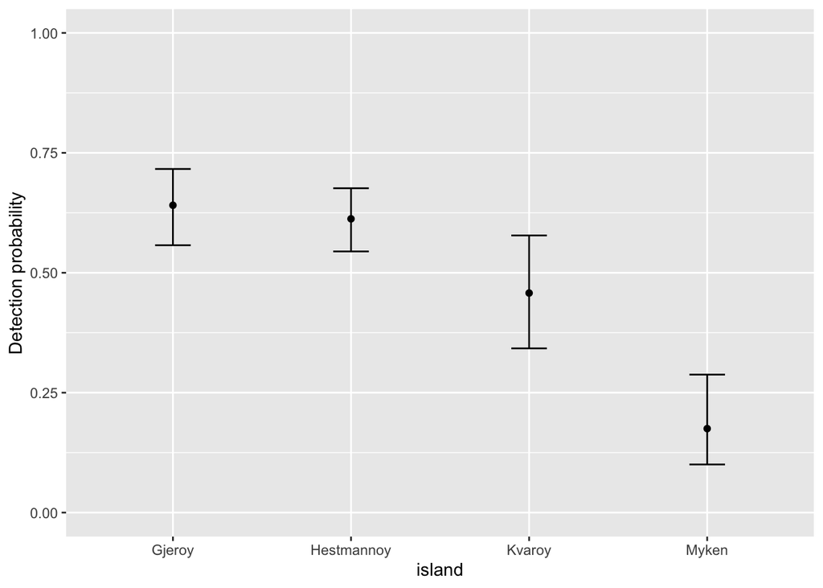

```r
mod4 <- sparrow.models[[2]]

ggplot(mod4$results$reals$p, aes(island, estimate, ymin=lcl, ymax=ucl)) +
  geom_errorbar(width=0.2) + geom_point() + ylim(0,1) + ylab('Detection probability')
```

We can also extract the sex and island differences in survival from the similarly supported models and plot those to convince ourselves that there aren’t big differences.

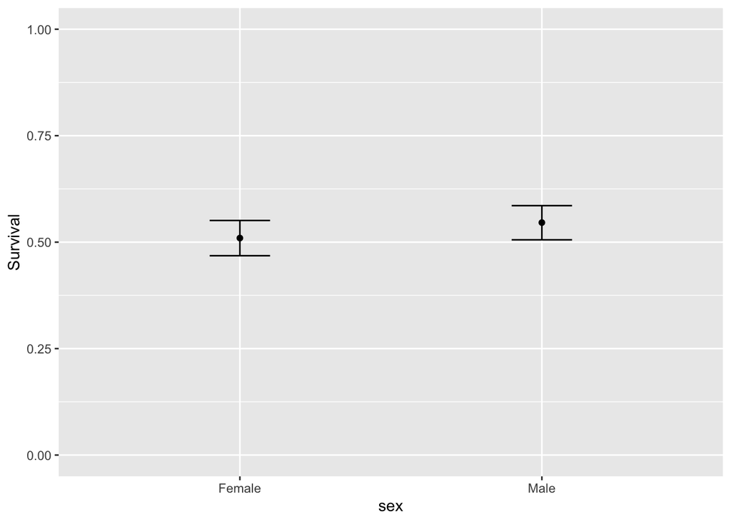

```r
mod5 <- sparrow.models[[10]]
ggplot(mod5$results$reals$Phi, aes(sex, estimate, ymin=lcl, ymax=ucl)) +
  geom_errorbar(width=0.2) + geom_point() + ylim(0,1) + ylab('Survival')
```

Can you do the same for island?

**Click me**

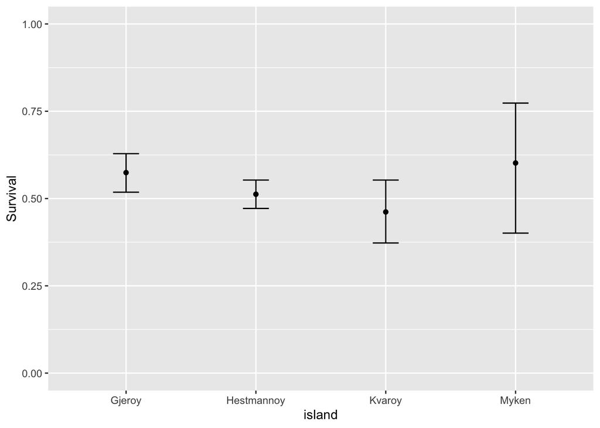

```r
mod6 <- sparrow.models[[6]]
ggplot(mod6$results$reals$Phi, aes(island, estimate, ymin=lcl, ymax=ucl)) +
  geom_errorbar(width=0.2) + geom_point() + ylim(0,1) + ylab('Survival')
```

## Including time-varying covariates

We might want to test whether survival (or detection) probabilities differ depending on a factor that varies over time, such as some aspect of the weather. As an example, we will add a variable ‘cold’ to the design data (sparrow.ddl) and test whether it being an extra-cold winter affects survival.

```r
sparrow.ddl$Phi$cold <- "Cold" # new column
sparrow.ddl$Phi$cold[sparrow.ddl$Phi$time==2 | sparrow.ddl$Phi$time==5 | sparrow.ddl$Phi$time==8] <- "VeryCold" # very cold winters between capture events 2 and 3, 5 and 6, and 8 and 9

head(sparrow.ddl$Phi)
```

```
##   id occ time cohort age island    sex freq Time Cohort Age order     cold
## 1  1   1    1      9   0 Gjeroy Female    8    0      8   0     1     Cold
## 2  1   2    2      9   0 Gjeroy Female    8    1      8   0     2 VeryCold
## 3  1   3    3      9   0 Gjeroy Female    8    2      8   0     3     Cold
## 4  1   4    4      9   0 Gjeroy Female    8    3      8   0     4     Cold
## 5  1   5    5      9   0 Gjeroy Female    8    4      8   0     5 VeryCold
## 6  1   6    6      9   0 Gjeroy Female    8    5      8   0     6     Cold
```

```r
Phi.cold <- list(formula=~cold)
p.island <- list(formula=~island)

mod7 <- crm(sparrow.proc,
            sparrow.ddl,
            model.parameters = list(Phi = Phi.cold,
                                    p = p.island),
            accumulate=FALSE, hessian = TRUE)
```

```r
mod7$results$reals
```

```
## $Phi
##       cold occ  estimate         se       lcl       ucl
## 1     Cold   9 0.5260721 0.02119546 0.4844444 0.5673404
## 2 VeryCold   8 0.5324049 0.03045722 0.4725301 0.5913607
##
## $p
##       island occ  estimate         se       lcl       ucl
## 1     Gjeroy  10 0.6407679 0.04085820 0.5574439 0.7163855
## 2 Hestmannoy  10 0.6124207 0.03380355 0.5444742 0.6762585
## 3     Kvaroy  10 0.4575759 0.06120658 0.3422137 0.5776744
## 4      Myken  10 0.1750406 0.04739879 0.1003201 0.2876225
```

```r
(mod7$results$AIC) # survival probability depends on cold, detection probability depends on island
```

```
## [1] 2424.932
```

```r
(mod4$results$AIC) # detection probability depends on island
```

```
## [1] 2422.957
```

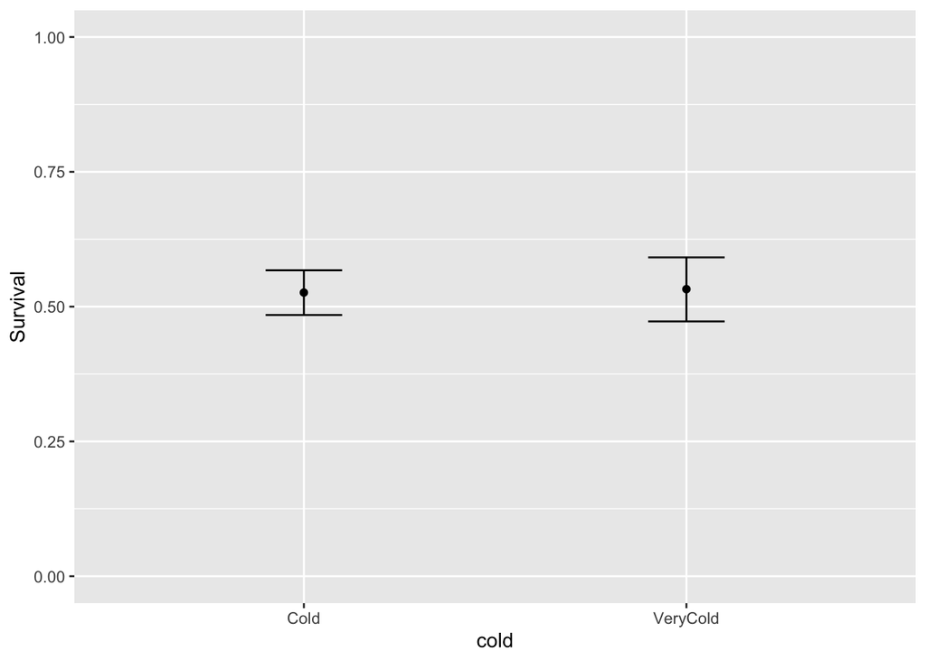

```r
ggplot(mod7$results$reals$Phi, aes(cold, estimate, ymin=lcl, ymax=ucl)) +
  geom_errorbar(width=0.2) + geom_point() + ylim(0,1) + ylab('Survival')
```

The model including an effect of cold on survival probability has a higher AIC, so there is no evidence that survival varied depending on our made-up variable. Phew!

## Time varying survival and recapture probabilities

Finally, we can test whether survival and detection probabilities varied each year of the study period using the built-in time variable.

```r
sparrow.proc <- process.data(sparrow)
sparrow.ddl <- make.design.data(sparrow.proc)

fit.models <- function() {
  Phi.dot <- list(formula=~1) # constant survival
  Phi.time <- list(formula=~time) # survival varies over time
  p.island <- list(formula=~island) # detection probability differs between islands
  p.time <- list(formula=~time) # detection probability varies over time
  p.island.time <- list(formula=~island+time) # detection probability varies over time and differs between islands
  cml <- create.model.list(c("Phi","p"))
  results <- crm.wrapper(cml, data=sparrow.proc, ddl=sparrow.ddl,
                         external=FALSE, accumulate=FALSE, hessian=TRUE)
  return(results)
}

sparrow.models <- fit.models() # run function
```

```r
sparrow.models # display model table
```

```
##                         model npar      AIC   DeltaAIC       weight  neg2lnl
## 2    Phi(~1)p(~island + time)   13 2386.456  0.0000000 5.382147e-01 2360.456
## 5 Phi(~time)p(~island + time)   21 2386.762  0.3063594 4.617751e-01 2344.762
## 4        Phi(~time)p(~island)   13 2409.262 22.8061195 6.007166e-06 2383.262
## 3             Phi(~1)p(~time)   10 2410.266 23.8098387 3.636761e-06 2390.266
## 6          Phi(~time)p(~time)   18 2413.945 27.4893116 5.777333e-07 2377.945
## 1           Phi(~1)p(~island)    5 2422.957 36.5009860 6.380683e-09 2412.957
##   convergence
## 2           0
## 5           0
## 4           0
## 3           0
## 6           0
## 1           0
```

```r
mod8 <- sparrow.models[[2]]

(mod8$results$AIC) # detection probability varies over time and depends on island
```

```
## [1] 2386.456
```

```r
(mod4$results$AIC) # detection probability depends on island
```

```
## [1] 2422.957
```

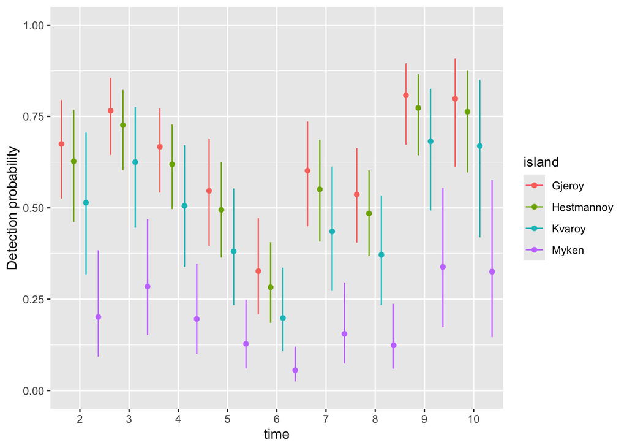

```r
ggplot(mod8$results$reals$p, aes(time, estimate, ymin=lcl, ymax=ucl, col=island, group=island)) +
  geom_errorbar(width=0, position=position_dodge(width=1)) + geom_point(position=position_dodge(width=1)) +
  ylim(0,1) + ylab('Detection probability')
```

It looks like detection probability was very low in some years of the study, but there isn’t strong support that survival probability varied with any of our tested covariates.

The next step in this analysis would be to conduct Goodness-of-fit tests to see whether our data violate the basic assumptions of the CJS model, which are that animals have equal detection probabilities and equal survival. For reference - the *R2ucare* package does this by testing whether detection depends on when an animal is first marked, and whether marking affects survival. However, we will stop here for now. In the next practical, we will take survival estimates from a CMR analysis and use them in a simple matrix population model for one of these island populations.